# Ecological models in NIMBLE: zero-inflated Poisson version of N-mixture model

NIMBLE 2023 Virtual Workshop

NIMBLE Development Team

January 2023

# Example: Swiss Great Tits

This examples is from [Applied Hierarchical Modeling in Ecology, Vol I](https://www.mbr-pwrc.usgs.gov/pubanalysis/keryroylebook/) (Kéry and Royle), Chapter 6, section 6.11.1.

[Tits in Europe](https://en.wikipedia.org/wiki/Great_tit) are birds in the family Paridae, which are called chickadees or titmice in North America.

This module uses packages `AHMbook` and `unmarked` for data setup, but the results are provided in the example directory, so you can just load the data from there (see code below).

# Introduction to N-mixture models for animal abundances in ecology

- Each site is surveyed multiple times within one season.
- Data: $y_{i,j}$ = number of detected birds (Great Tits) at site $i$ on survey $j$.
- Each site has predicted density $\lambda_{i}$.
- Each site has a latent true number of animals that could be detected, $N_i \sim \mbox{Poisson}(\lambda_i)$.
- In the example, this is extended to a zero-inflated Poisson: There is a probability that a site has a “structural $N_{i}=0$” due to lack of suitable habitat. Otherwise $N_i \sim \mbox{Poisson}(\lambda_i)$
- $N_i$ does not change between surveys.
- On survey $j$ to site $i$, each bird is detected with probability, $p_{i, j}$.
- Number of birds detected on a survey is binomial: $y_{i,j} \sim \mbox{binom}(N_i, p_{i,j})$
- Marginal probability of data at site $i$ requires summation over $N_i$ (an infinite summation that is truncated in practice):

$$\sum_{N_{i}=0}^{\infty} \prod_{j = 1}^{\mbox{# surveys}}
\mbox{dbinom}(y_{i,j} | N_{i}, p_{i,j}) \mbox{dpois}(N_{i} |
\lambda_{i})$$

# Data summary for Swiss Great Tits example

# Prepare data and show figure from book

Let’s run the original book code and generate its figure(s). (See next slide if you just want to load the prepared data.)

```r
if(!exists("DO_PLOT"))
    DO_PLOT <- FALSE

library(AHMbook)
## Code modified to use the SwissTits data set included in the AHMbook package
data(SwissTits)
str(SwissTits)
```

```
## List of 5
##  $ species:'data.frame': 6 obs. of  3 variables:
##   ..$ specid : int [1:6] 3790 3800 3820 3830 3860 3870
##   ..$ latname: chr [1:6] "PARMAJ" "PARCAE" "PARATE" "PARCRI" ...
##   ..$ name   : chr [1:6] "Great tit" "Blue tit" "Coal tit" "Crested tit" ...
##  $ sites  :'data.frame': 267 obs. of  9 variables:
##   ..$ siteID   : chr [1:267] "Q001" "Q002" "Q003" "Q004" ...
##   ..$ coordx   : int [1:267] 922942 928942 928942 934942 934942 946942 946942 952942 958942 958942 ...
##   ..$ coordy   : int [1:267] 63276 79276 103276 95276 111276 95276 111276 119276 111276 127276 ...
##   ..$ AQ       : int [1:267] 1 2 3 3 4 5 6 7 9 10 ...
##   ..$ AQ.coordx: int [1:267] 920442 930942 930942 930942 930942 950942 950942 950942 960942 960942 ...
##   ..$ AQ.coordy: int [1:267] 170224 190724 210724 210724 220724 210724 220724 230724 220724 240724 ...
##   ..$ elev     : int [1:267] 450 450 1050 950 1150 550 750 650 550 550 ...
##   ..$ rlength  : num [1:267] 6.4 5.5 4.3 4.5 5.4 3.6 3.9 6.1 5.8 4.5 ...
##   ..$ forest   : int [1:267] 3 21 32 9 35 2 6 60 5 13 ...
##  $ counts : num [1:267, 1:3, 1:10, 1:6] NA 21 2 NA 4 NA 11 4 NA NA ...
##   ..- attr(*, "dimnames")=List of 4
##   .. ..$ site   : chr [1:267] "Q001" "Q002" "Q003" "Q004" ...
##   .. ..$ rep    : chr [1:3] "1" "2" "3"
##   .. ..$ year   : chr [1:10] "2004" "2005" "2006" "2007" ...
##   .. ..$ species: chr [1:6] "Great tit" "Blue tit" "Coal tit" "Crested tit" ...
##  $ date   : int [1:267, 1:3, 1:10] 28 23 25 24 22 27 20 21 34 20 ...
##   ..- attr(*, "dimnames")=List of 3
##   .. ..$ site: chr [1:267] "Q001" "Q002" "Q003" "Q004" ...
##   .. ..$ rep : chr [1:3] "1" "2" "3"
##   .. ..$ year: chr [1:10] "2004" "2005" "2006" "2007" ...
##  $ dur    : int [1:267, 1:3, 1:10] 240 175 215 180 180 300 215 200 135 150 ...
##   ..- attr(*, "dimnames")=List of 3
##   .. ..$ site: chr [1:267] "Q001" "Q002" "Q003" "Q004" ...
##   .. ..$ rep : chr [1:3] "1" "2" "3"
##   .. ..$ year: chr [1:10] "2004" "2005" "2006" "2007" ...
```

```r
SwissTits$species  # Available species
```

```
##   specid latname        name
## 1   3790  PARMAJ   Great tit
## 2   3800  PARCAE    Blue tit
## 3   3820  PARATE    Coal tit
## 4   3830  PARCRI Crested tit
## 5   3860  PARPAL   Marsh tit
## 6   3870  PARMON  Willow tit
```

```r
# Select Great tit and covariate data from 2013 and
#   drop 4 sites not surveyed in 2013
y0 <- SwissTits$counts[, , '2013', 'Great tit']
( NA.sites <- which(rowSums(is.na(y0)) == 3) ) # Unsurveyed sites
```

```
## Q119 Q160 Q188 Q248
##  119  160  188  248
```

```r
y <- y0[-NA.sites, ]                 # Drop them from the count data
tits <- SwissTits$sites[-NA.sites, ] # Also drop from the site covariates
str(y)  # Check the matrix of count data
```

```
##  num [1:263, 1:3] 25 20 4 12 0 4 12 7 10 5 ...
##  - attr(*, "dimnames")=List of 2
##   ..$ site: chr [1:263] "Q001" "Q002" "Q003" "Q004" ...
##   ..$ rep : chr [1:3] "1" "2" "3"
```

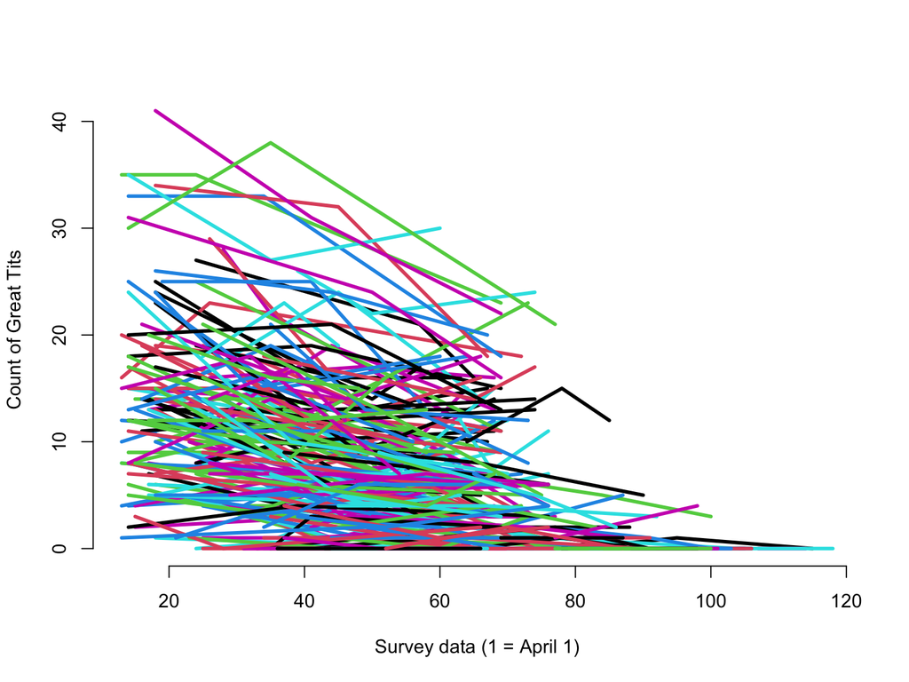

```r
# Get date and duration data for 2013, without the NA.sites rows:
date <- SwissTits$date[-NA.sites, , '2013']
dur <- SwissTits$dur[-NA.sites, , '2013']

# Plot observed data: counts vs survey date (Fig. 6-9)
if(DO_PLOT) matplot(t(date), t(y), type = "l", lwd = 3, lty = 1, frame = F, xlab = "Survey data (1 = April 1)", ylab = "Count of Great Tits")
```

```r
# Load unmarked, create unmarked data frame and inspect result
library(unmarked)
time <- matrix(rep(as.character(1:3), nrow(y)), ncol = 3, byrow = TRUE)
umf <- unmarkedFramePCount(y = y,
                           siteCovs=data.frame(elev=scale(tits[,"elev"]), forest=scale(tits[,"forest"]), iLength=1/tits[,"rlength"]),
                           obsCovs=list(time = time, date = scale(date), dur = scale(dur)))
summary(umf)                            # Summarize unmarked data frame
```

```
## unmarkedFrame Object
##
## 263 sites
## Maximum number of observations per site: 3
## Mean number of observations per site: 2.83
## Sites with at least one detection: 191
##
## Tabulation of y observations:
##    0    1    2    3    4    5    6    7    8    9   10   11   12   13   14   15
##  215   45   32   33   42   34   37   34   26   24   24   20   24   23   19   18
##   16   17   18   19   20   21   22   23   24   25   26   27   28   29   30   31
##   16    8   12    8    4    6    3    5    7    5    2    2    1    1    2    2
##   32   33   34   35   38   41 <NA>
##    1    2    1    3    1    1   46
##
## Site-level covariates:
##       elev              forest           iLength
##  Min.   :-1.46576   Min.   :-1.2571   Min.   :0.1064
##  1st Qu.:-0.99774   1st Qu.:-0.9508   1st Qu.:0.1695
##  Median :-0.06169   Median :-0.0677   Median :0.1961
##  Mean   : 0.00000   Mean   : 0.0000   Mean   :0.2099
##  3rd Qu.: 1.03036   3rd Qu.: 0.7793   3rd Qu.:0.2326
##  Max.   : 2.43443   Max.   : 2.3112   Max.   :0.8333
##
## Observation-level covariates:
##  time         date              dur
##  1:263   Min.   :-2.0395   Min.   :-2.67940
##  2:263   1st Qu.:-0.7859   1st Qu.:-0.67188
##  3:263   Median :-0.2417   Median :-0.01575
##          Mean   : 0.0000   Mean   : 0.00000
##          3rd Qu.: 0.5073   3rd Qu.: 0.65899
##          Max.   : 3.7113   Max.   : 3.23391
##          NA's   :46        NA's   :46
```

```r
summary(apply(y, 1, max, na.rm = TRUE)) # Summarize max counts
```

```
##    Min. 1st Qu.  Median    Mean 3rd Qu.    Max.
##   0.000   0.000   6.000   8.354  14.000  41.000
```

```r
elev <- umf@siteCovs$elev   ;   elev2 <- elev^2
forest <- umf@siteCovs$forest   ;   forest2 <- forest^2
date <- matrix(umf@obsCovs$date, ncol = 3, byrow = TRUE)
dur <- matrix(umf@obsCovs$dur, ncol = 3, byrow = TRUE)
date[is.na(date)] <- 0   ;   date2 <- date^2
dur[is.na(dur)] <- 0   ;   dur2 <- dur^2
iRoute <- umf@siteCovs$iLength

# Design matrix for abundance model (no intercept)
lamDM <- model.matrix(~ elev + elev2 + forest + forest2 + elev:forest + elev:forest2 + iRoute)[,-1]

# Initial values
Nst <- apply(y, 1, max, na.rm = T) + 1
Nst[is.na(Nst)] <- round(mean(y, na.rm = TRUE))
Nst[Nst == "-Inf"] <- round(mean(y, na.rm = TRUE))
SGT_inits <- function(){ list(N = Nst,
                              beta0 = 0,
                              mean.p = rep(0.5, 3),
                              beta = runif(7, 0, 0),
                              alpha = runif(13, 0, 0)
                              )}


# Bundle data and choose to fit simple ZIP model (model 1)
SGT_data1 <- list(y = y,
                  lamDM = lamDM,
                  elev = elev,
                  date = date,
                  dur = dur,
                  elev2 = elev2,
                  date2 = date2,
                  dur2 = dur2,
                  e = 1e-06,
                  hlam.on = 1,      # Three toggles for model components - discusss
                  hp.site.on = 1,
                  hp.survey.on = 1,
                  nsite = 263,
                  nrep = 3)

save(SGT_data1, Nst, SGT_inits, file = file.path("..", "examples", "SwissGreatTits", "prepared_data.RData"))
```

# Load the prepared data and inits function

```r
load(file = file.path("..", "examples", "SwissGreatTits", "prepared_data.RData"))
```

# Model code

Here is the original model code from AHM section 6.11.

```r
Section6p11_code <- nimbleCode( {

  # Specify priors
  # zero-inflation/suitability
  phi ~ dunif(0,1)          # proportion of suitable sites (probability of being not a structural 0)
  theta <- 1-phi            # zero-inflation (proportion of unsuitable)
  ltheta <- logit(theta)

  # abundance
  beta0 ~ dnorm(0, 0.1)     # log(lambda) intercept
  for(k in 1:7){            # Regression params in lambda
    beta[k] ~ dnorm(0, 1)
  }
  tau.lam <- pow(sd.lam, -2)
  sd.lam ~ dunif(0, 2)      # site heterogeneity in lambda

  # detection
  for(j in 1:3){
    alpha0[j] <- logit(mean.p[j])
    mean.p[j] ~ dunif(0, 1) # p intercept for occasions 1-3
  }
  for(k in 1:13){           # Regression params in p
    alpha[k] ~ dnorm(0, 1)
  }
  tau.p.site <- pow(sd.p.site, -2)
  sd.p.site ~ dunif(0, 2)   # site heterogeneity in p
  tau.p.survey <- pow(sd.p.survey, -2)
  sd.p.survey ~ dunif(0, 2) # site-survey heterogeneity in p

  # ZIP model for abundance
  for (i in 1:nsite){
    a[i] ~ dbern(phi)
    eps.lam[i] ~ dnorm(0, tau.lam)       # Random site effects in log(abundance)
    loglam[i] <- beta0 + inprod(beta[1:7], lamDM[i, 1:7]) + eps.lam[i] * hlam.on
    loglam.lim[i] <- min(250, max(-250, loglam[i]))  # Stabilize log
    lam[i] <- exp(loglam.lim[i])
    mu.poisson[i] <- a[i] * lam[i]
    N[i] ~ dpois(mu.poisson[i])
  }

  # Measurement error model
  for (i in 1:nsite){
    eps.p.site[i] ~ dnorm(0, tau.p.site) # Random site effects in logit(p)
    for (j in 1:nrep){
      y[i,j] ~ dbin(p[i,j], N[i])
      p[i,j] <- 1 / (1 + exp(-lp.lim[i,j]))
      lp.lim[i,j] <- min(250, max(-250, lp[i,j]))  # Stabilize logit
      lp[i,j] <- alpha0[j] + alpha[1] * elev[i] + alpha[2] * elev2[i] +
        alpha[3] * date[i,j] + alpha[4] * date2[i,j] +
        alpha[5] * dur[i,j] + alpha[6] * dur2[i,j] +
        alpha[7] * elev[i] * date[i,j] + alpha[8] * elev2[i] * date[i,j] +
        alpha[9] * elev[i] * dur[i,j] + alpha[10] * elev[i] * dur2[i,j] +
        alpha[11] * elev2[i] * dur[i,j] + alpha[12] * date[i,j] * dur[i,j] +
        alpha[13] * date[i,j] * dur2[i,j] +
        eps.p.site[i] * hp.site.on + eps.p.survey[i,j] * hp.survey.on
      eps.p.survey[i,j] ~ dnorm(0, tau.p.survey) # Random site-survey effects
    }
  }
  if(DO_POSTERIOR_PREDICTION) {
    # Posterior predictive distributions of chi2 discrepancy
    for (i in 1:nsite) {
      for (j in 1:nrep) {
        y.sim[i,j] ~ dbin(p[i,j], N[i]) # Create new data set under model
        e.count[i,j] <- N[i] * p[i,j]   # Expected datum
        # Chi-square discrepancy for the actual data
        chi2.actual[i,j] <- pow((y[i,j]-e.count[i,j]),2) / (e.count[i,j]+e)
        # Chi-square discrepancy for the simulated ('perfect') data
        chi2.sim[i,j] <- pow((y.sim[i,j]-e.count[i,j]),2) / (e.count[i,j]+e)
        # Add small value e to denominator to avoid division by zero
      }
    }
    # Add up individual chi2 values for overall fit statistic
    fit.actual <- sum(chi2.actual[1:263, 1:3])  # Fit statistic for actual data set
    fit.sim <- sum(chi2.sim[1:263, 1:3])        # Fit statistic for a fitting model
    bpv <- step(fit.sim-fit.actual)    # Bayesian p-value
    c.hat <- fit.actual/fit.sim        # c-hat estimate

    # Derived parameters: Total abundance at 263 sampled sites
    Ntotal263 <- sum(N[1:263])
  }
}
)
```

Discussion points

- Definition-time if-then-else
- The “on” toggling variables are (very) inefficient.
- What nodes share the same dependencies? Can anything be grouped / vectorized?
- Some of the runs in this module take a long time (up to 50 minutes for the slowest one on a 2019 MacBook Pro).

# Try building the model

```r
DO_POSTERIOR_PREDICTION <- FALSE
m <- nimbleModel(Section6p11_code,
                 constants = SGT_data1,
                 inits = SGT_inits())
```

```
## Defining model
```

```
##   [Note] Using 'y' (given within 'constants') as data.
```

```
## Building model
```

```
## Setting data and initial values
```

```
## Running calculate on model
##   [Note] Any error reports that follow may simply reflect missing values in model variables.
```

```
## Checking model sizes and dimensions
```

```
##   [Note] This model is not fully initialized. This is not an error.
##          To see which variables are not initialized, use model$initializeInfo().
##          For more information on model initialization, see help(modelInitialization).
```

```r
## What is the warning about?
m$initializeInfo()
```

```
##   [Note] Missing values (NAs) or non-finite values were found in model variables: phi, theta, ltheta, tau.lam, sd.lam, tau.p.site, sd.p.site, tau.p.survey, sd.p.survey, a, lifted_d1_over_sqrt_oPtau_dot_lam_cP, eps.lam, loglam, loglam.lim, lam, mu.poisson, lifted_d1_over_sqrt_oPtau_dot_p_dot_site_…
##   [Note] This is not an error, but some or all variables may need to be initialized for certain algorithms to operate properly.
##   [Note] For more information on model initialization, see help(modelInitialization).
```

```r
m$phi
```

```
## [1] NA
```

```r
head(m$eps.p.survey)
```

```
##      [,1] [,2] [,3]
## [1,]   NA   NA   NA
## [2,]   NA   NA   NA
## [3,]   NA   NA   NA
## [4,]   NA   NA   NA
## [5,]   NA   NA   NA
## [6,]   NA   NA   NA
```

### Observations

- We see not everything is initialized.
- It is ok not to initialize everything, but NIMBLE and JAGS may have different complaints.
- NIMBLE models can be initialized after creation, not just by `inits` argument.
- We’ll want more complete `inits` later that what was provided in the AHM code, so I wrote a more complete one here:

```r
SGT_inits_full<- function(){
    ans <- list(N = Nst,
                beta0 = 0,
                mean.p = rep(0.5, 3),
                beta = runif(7, 0, 0),
                alpha = runif(13, 0, 0)
              , phi = 0.5
              , sd.lam = 1
              , sd.p.site = 1
              , sd.p.survey = 1
              , a = rbinom(SGT_data1$nsite, prob = 0.5, size = 1)
              , eps.lam = rnorm(SGT_data1$nsite)
              , eps.p.site = rnorm(SGT_data1$nsite)
              , eps.p.survey = matrix(rnorm(SGT_data1$nsite * SGT_data1$nrep),
                                      nrow = SGT_data1$nsite)
                )
    ans$a[ ans$N > 0 ] <- 1
    ans
}
```

# Try building the model with complete inits

```r
m1 <- nimbleModel(Section6p11_code,
                 constants = SGT_data1,
                 inits = SGT_inits_full())
```

```
## Defining model
```

```
##   [Note] Using 'y' (given within 'constants') as data.
```

```
## Building model
```

```
## Setting data and initial values
```

```
## Running calculate on model
##   [Note] Any error reports that follow may simply reflect missing values in model variables.
```

```
## Checking model sizes and dimensions
```

```
##   [Note] This model is not fully initialized. This is not an error.
##          To see which variables are not initialized, use model$initializeInfo().
##          For more information on model initialization, see help(modelInitialization).
```

```r
m1$initializeInfo()
```

```
##   [Note] Missing values (NAs) or non-finite values were found in model variables: y.
##   [Note] This is not an error, but some or all variables may need to be initialized for certain algorithms to operate properly.
##   [Note] For more information on model initialization, see help(modelInitialization).
```

```r
## The only nodes left not initialized are parts of y
m1$y
```

```
##       rep
## site    1  2  3
##   Q001 25 16 16
##   Q002 20 10 12
##   Q003  4  4  1
##   Q004 12 11  6
##   Q005  0  1  0
##   Q006  4  1  4
##   Q007 12 11  4
##   Q008  7 10  5
##   Q009 10 14  4
##   Q010  5  6  6
##   Q011  4  3  1
##   Q012 13 15 11
##   Q013  6  3  3
##   Q014 16 23 18
##   Q015  6  4  6
##   Q016 11  4  6
##   Q017  8  7  6
##   Q018  3  9  3
##   Q019  9  2  2
##   Q020 14 12  8
##   Q021 35 35 23
##   Q022  4  5  7
##   Q023  7  7  9
##   Q024 10  4 15
##   Q025  0  0  1
##   Q026 19 10  6
##   Q027  7  5  3
##   Q028  0  0  0
##   Q029  5  0  1
##   Q030  2  3  3
##   Q031 13 13 15
##   Q032 10  5  3
##   Q033  7  2  4
##   Q034 10 13  8
##   Q035  1  3  4
##   Q036  4  3  3
##   Q037 11 12 10
##   Q038 11  8  9
```

[output cut: 210 more lines]

```
##   Q253  6  4  7
##   Q254  7  4 NA
##   Q255  0  0 NA
##   Q256  0  0 NA
##   Q257  0  0 NA
##   Q258  0  0  0
##   Q259  0  0 NA
##   Q260  0  0 NA
##   Q261  0  0  0
##   Q262  1  0  0
##   Q263  0  0  0
##   Q264  0  2  0
##   Q265  0  0 NA
##   Q266  3  2  4
##   Q267  9  5  2
```

```r
## The missing data are ok: they are really missing y values from rep 3.
## Note, in this case we don't need these sampled, but they will be.
```

# Mixing and computational cost of the original model

Note: sometimes costs change a bit after an algorithm has warmed up or done early iterations.

```r
MCMC1 <- buildMCMC(m1)
```

```
## ===== Monitors =====
## thin = 1: alpha, beta, beta0, mean.p, phi, sd.lam, sd.p.site, sd.p.survey
## ===== Samplers =====
## slice sampler (263)
##   - N[]  (263 elements)
## RW sampler (1297)
##   - phi
##   - beta0
##   - beta[]  (7 elements)
##   - sd.lam
##   - mean.p[]  (3 elements)
##   - alpha[]  (13 elements)
##   - sd.p.site
##   - sd.p.survey
##   - eps.lam[]  (263 elements)
##   - eps.p.site[]  (263 elements)
##   - eps.p.survey[]  (743 elements)
## posterior_predictive sampler (46)
##   - eps.p.survey[]  (46 elements)
## binary sampler (263)
##   - a[]  (263 elements)
## ===== Comments =====
```

```
##   [Note] Additional downstream predictive nodes are also being sampled by posterior_predictive sampler
```

```r
compiled1 <- compileNimble(m1, MCMC1)
```

```
## Compiling
##   [Note] This may take a minute.
##   [Note] Use 'showCompilerOutput = TRUE' to see C++ compilation details.
```

```r
## See that it runs for small number of iterations
compiled1$MCMC1$run(10)
```

```r
## We saw reports of an initialization problem above,
## so let's do some manual calculation to check
compiled1$m1$calculate()
```

```
## [1] -3492.802
```

```r
## We see the compiled model is now fully
## initialized and has a valid total logProb.
m1$calculate()
```

```
## [1] NA
```

```r
## We see the uncompiled model (with original inits)
## does not give a valid logProb.
m1$logProb_y
```

```
##                [,1]         [,2]         [,3]
##   [1,]  -2.85004472  -3.20158650  -5.42389551
##   [2,]  -0.97971078  -4.69538352  -5.10375536
##   [3,]  -2.11154033  -2.84209106  -1.55159856
##   [4,] -12.11044325 -20.81239848  -1.61872171
##   [5,]  -0.91240379  -0.79985271  -0.79628412
##   [6,]  -2.39682479  -1.20018980  -1.08241620
##   [7,] -22.06377641  -7.67386006  -3.40469819
##   [8,]  -5.99382373  -6.75945535  -1.95717108
##   [9,]  -3.42645139  -9.50122071  -2.58274663
##  [10,]  -3.45405414 -14.26394056 -10.85752017
##  [11,]  -0.92073706  -3.67330416 -14.18989906
##  [12,]  -1.39370603  -6.92481099  -2.67882901
##  [13,]  -3.53565089  -1.84189695  -2.61966914
##  [14,]  -2.08732678  -1.27489267  -8.21466466
```

[output cut: 249 more lines]

```r
## We see the problem is missing parts of y
m1$calculate("y")
```

```
## [1] NA
```

```r
## Indeed, calculating logProbs just of y gives NA
compiled1$m1$calculate("y")
```

```
## [1] -944.5685
```

```r
## But again the compiled model is ok after
## MCMC initialization.

## Conclusion: What we see is that elements of y that are missing
## data make the model start with invalid log probability.
## That may not be a problem.  Those nodes will be
## initialized from their priors, so if those give decent
## values, there will be no problem.
## more later.  For now, we will move on.

## Note that when code encounters NAs or NaNs,
## it may run slower.
```

# Run nimble’s default MCMC for the original model

```r
comparison1 <- compareMCMCs(modelInfo = list(model = m1),
                            MCMCcontrol = list(niter = 120000, nburnin = 20000, thin = 100))
save(comparison1, file = file.path(save_dir, "ZIPNmix_case1.Rdata"))
```

# Mixing and computational cost of the original model

```r
# How long did 120000 iterations take?
comparison1$nimble$times$sampling
```

```
## elapsed
## 366.727
```

```r
# Mixing and efficiency
comparison1$nimble$metrics
```

```
## $byMCMC
##     MCMC min_efficiency mean_efficiency
## 1 nimble      0.0921355       0.7282351
##
## $byParameter
##      MCMC   Parameter         mean       median         sd    CI95_low
## 1  nimble    alpha[1] -1.552677452 -1.567573606 0.34858262 -2.27460687
## 2  nimble   alpha[10]  0.185902822  0.185657405 0.06678605  0.06376441
## 3  nimble   alpha[11]  0.374147333  0.374034859 0.12855625  0.12679291
## 4  nimble   alpha[12] -0.023754001 -0.019046310 0.08014513 -0.19169403
## 5  nimble   alpha[13] -0.092770196 -0.091762598 0.06067328 -0.22528582
## 6  nimble    alpha[2] -0.543847155 -0.540156048 0.29219211 -1.20442643
## 7  nimble    alpha[3] -0.102119148 -0.101996048 0.13556257 -0.35930216
## 8  nimble    alpha[4]  0.069137660  0.068513611 0.07712962 -0.08037915
## 9  nimble    alpha[5] -0.008133840 -0.010900972 0.11274445 -0.21259995
```

[output cut: 51 more lines]

# Run JAGS for the original model

Code is modified by deleting the posterior predictive nodes portion (which was excluded for nimble using a definition-time if-then-else, which is not supported by JAGS.)

```r
comparison1jags <- compareMCMCs(modelInfo =
                                  list(code = Section6p11_code_jags, constants = SGT_data1, inits = SGT_inits_full()),
                                MCMCcontrol = list(niter = 120000, nburnin = 20000, thin = 100),
                                MCMCs = "jags")
save(comparison1jags, file = file.path(save_dir, "ZIPNmix_case1jags.Rdata"))
```

# Mixing and computational cost of JAGS for the original model

```r
# How long did 120000 iterations take?
comparison1jags$jags$times$sampling
```

```
## elapsed
## 1929.93
```

```r
# Mixing and efficiency
comparison1jags$jags$metrics
```

```
## $byMCMC
##   MCMC min_efficiency mean_efficiency
## 1 jags     0.03124792       0.1902614
##
## $byParameter
##    MCMC   Parameter         mean      median         sd    CI95_low    CI95_upp
## 1  jags    alpha[1] -1.554140091 -1.54044234 0.33067431 -2.22358535 -0.94236763
## 2  jags   alpha[10]  0.182128731  0.17848086 0.06535110  0.05890714  0.31058180
## 3  jags   alpha[11]  0.351239556  0.34435960 0.13291080  0.10207073  0.61570806
## 4  jags   alpha[12] -0.007325309 -0.00693036 0.07627521 -0.16263201  0.13908820
## 5  jags   alpha[13] -0.082757372 -0.08219160 0.05679114 -0.20028342  0.02723528
## 6  jags    alpha[2] -0.533952200 -0.53012542 0.30953398 -1.17728260  0.02006639
## 7  jags    alpha[3] -0.101751629 -0.10219429 0.12341254 -0.33733820  0.13458188
## 8  jags    alpha[4]  0.065550463  0.06427893 0.07261214 -0.07942955  0.21467959
## 9  jags    alpha[5] -0.013167465 -0.01594422 0.11447367 -0.23221135  0.20266025
```

[output cut: 51 more lines]

# Discuss inefficiency of the toggle nodes

- The `hlam.on`, `hp.site.on`, and `hp.survey.on` nodes serve as toggles for three sets of random effects.
- This is an inefficient way to turn off random effects.
- The MCMC system will not know that the corresponding random effects do not need to be sampled.
- Computation time will be wasted sampling nodes that have no impact on the model.
- In this worked example, all three sets of random effects are “on”, so we will proceed with the code as is.

# Group related calculations

```r
Section6p11_code_grouped <- nimbleCode( {
  # Specify priors
  # zero-inflation/suitability
  phi ~ dunif(0,1)          # proportion of suitable sites (probability of being not a structural 0)
  theta <- 1-phi            # zero-inflation (proportion of unsuitable)
  ltheta <- logit(theta)

  # abundance
  beta0 ~ dnorm(0, 0.1)     # log(lambda) intercept
  for(k in 1:7){            # Regression params in lambda
    beta[k] ~ dnorm(0, 1)
  }
  tau.lam <- pow(sd.lam, -2)
  sd.lam ~ dunif(0, 2)      # site heterogeneity in lambda

  # detection
  for(j in 1:3){
    alpha0[j] <- logit(mean.p[j])
    mean.p[j] ~ dunif(0, 1) # p intercept for occasions 1-3
  }
  for(k in 1:13){           # Regression params in p
    alpha[k] ~ dnorm(0, 1)
  }
  tau.p.site <- pow(sd.p.site, -2)
  sd.p.site ~ dunif(0, 2)   # site heterogeneity in p
  tau.p.survey <- pow(sd.p.survey, -2)
  sd.p.survey ~ dunif(0, 2) # site-survey heterogeneity in p

  # ZIP model for abundance
  # new
  loglam.fixed[1:nsite] <- beta0 + (lamDM[1:nsite, 1:7] %*% beta[1:7])[1:nsite,1]
  for (i in 1:nsite){
    a[i] ~ dbern(phi)
    eps.lam[i] ~ dnorm(0, tau.lam)       # Random site effects in log(abundance)
    loglam[i] <- loglam.fixed[i] + eps.lam[i] * hlam.on
    loglam.lim[i] <- min(250, max(-250, loglam[i]))  # Stabilize log
    lam[i] <- exp(loglam.lim[i])
    mu.poisson[i] <- a[i] * lam[i]
    N[i] ~ dpois(mu.poisson[i])
  }
  # Measurement error model
  # new
  for(j in 1:nrep) {
    lp.fixed[1:nsite,j] <- alpha0[j] + alpha[1] * elev[1:nsite] + alpha[2] * elev2[1:nsite] +
      alpha[3] * date[1:nsite,j] + alpha[4] * date2[1:nsite,j] +
      alpha[5] * dur[1:nsite,j] + alpha[6] * dur2[1:nsite,j] +
      alpha[7] * elev[1:nsite] * date[1:nsite,j] + alpha[8] * elev2[1:nsite] * date[1:nsite,j] +
      alpha[9] * elev[1:nsite] * dur[1:nsite,j] + alpha[10] * elev[1:nsite] * dur2[1:nsite,j] +
      alpha[11] * elev2[1:nsite] * dur[1:nsite,j] + alpha[12] * date[1:nsite,j] * dur[1:nsite,j] +
      alpha[13] * date[1:nsite,j] * dur2[1:nsite,j]
  }

  for (i in 1:nsite){
    eps.p.site[i] ~ dnorm(0, tau.p.site) # Random site effects in logit(p)
    for (j in 1:nrep){
      y[i,j] ~ dbin(p[i,j], N[i])
      p[i,j] <- 1 / (1 + exp(-lp.lim[i,j]))
      lp.lim[i,j] <- min(250, max(-250, lp[i,j]))  # Stabilize logit

      ## new
      lp[i,j] <- lp.fixed[i, j] +
        eps.p.site[i] * hp.site.on + eps.p.survey[i,j] * hp.survey.on

      eps.p.survey[i,j] ~ dnorm(0, tau.p.survey) # Random site-survey effects
    }
  }
}
)
```

# Run with grouped calculations

```r
m2 <- nimbleModel(Section6p11_code_grouped,
                 constants = SGT_data1,
                 inits = SGT_inits_full())
comparison2 <- compareMCMCs(modelInfo = list(model = m2),
                            MCMCcontrol = list(niter = 120000, nburnin = 20000, thin = 100))
save(comparison2, file = file.path(save_dir, "ZIPNmix_case2.Rdata"))
```

# Results from grouped calculations

```r
# How long did 120000 iterations take?
comparison2$nimble$times$sampling
```

```
## elapsed
## 343.001
```

```r
# Mixing and efficiency
comparison2$nimble$metrics
```

```
## $byMCMC
##     MCMC min_efficiency mean_efficiency
## 1 nimble      0.1329968       0.7275161
##
## $byParameter
##      MCMC   Parameter         mean       median         sd    CI95_low
## 1  nimble    alpha[1] -1.541642693 -1.542484423 0.35638912 -2.23146579
## 2  nimble   alpha[10]  0.191695364  0.189476280 0.07177044  0.05348297
## 3  nimble   alpha[11]  0.357924295  0.362444476 0.13432891  0.09978596
## 4  nimble   alpha[12] -0.018338703 -0.014207716 0.08116470 -0.19242654
## 5  nimble   alpha[13] -0.095359345 -0.093272287 0.06041665 -0.22262643
## 6  nimble    alpha[2] -0.589518930 -0.598773464 0.31045216 -1.17087022
## 7  nimble    alpha[3] -0.101568976 -0.099670779 0.13524831 -0.37420492
## 8  nimble    alpha[4]  0.077934470  0.080685076 0.07270239 -0.06290984
## 9  nimble    alpha[5] -0.001833698 -0.002670608 0.12039580 -0.24516877
```

[output cut: 51 more lines]

# N-mixture models in `nimbleEcology`

Basic version: Poisson-binomial mixture distribution of abundance.

- `lambda` = Poisson mean
- `prob[k]` = detection probability on survey `k`.
- `Nmin` = start of summation range (or -1)
- `Nmax` = end of summation range (or -1)
- `len` = number of counts (surveys)

If `Nmin` and `Nmax` are both `-1`, a range of summation is determined automatically.

### Time-varying vs time-independent detection probabilities:

- `dNmixture_s` : time-independent detection probability (scalar)
- `dNmixture_v` : time-varying detection probability (vector)

### Extensions for over-dispersion:

- `dNmixture_BNB_s` and `dNmixture_BNB_v`: Binomial detection. Negative binomial abundance.
- `dNmixture_BBP_s` and `dNmixture_BBP_v`: Beta-binomial detection. Poisson abundance.
- `dNmixture_BBNB_s` and `dNmixture_BBBN_v`: Beta-binomial detection. Negative binomial abundance.

### Example usage

```r
y[i, 1:num_surveys] ~ dNmixture_v(lambda[i],
                                 prob[1:num_surveys],
                                 Nmin = -1, Nmax = -1,
                                 len = num_surveys)
```

# Use dNmixture

```r
Section6p11_code_dNmixture <- nimbleCode( {
  phi ~ dunif(0,1)          # proportion of suitable sites (probability of being not a structural 0)
  theta <- 1-phi            # zero-inflation (proportion of unsuitable)
  ltheta <- logit(theta)

  beta0 ~ dnorm(0, 0.1)     # log(lambda) intercept
  for(k in 1:7){            # Regression params in lambda
    beta[k] ~ dnorm(0, 1)
  }
  tau.lam <- pow(sd.lam, -2)
  sd.lam ~ dunif(0, 2)      # site heterogeneity in lambda

  # detection
  for(j in 1:3){
    alpha0[j] <- logit(mean.p[j])
    mean.p[j] ~ dunif(0, 1) # p intercept for occasions 1-3
  }
  for(k in 1:13){           # Regression params in p
    alpha[k] ~ dnorm(0, 1)
  }
  tau.p.site <- pow(sd.p.site, -2)
  sd.p.site ~ dunif(0, 2)   # site heterogeneity in p
  tau.p.survey <- pow(sd.p.survey, -2)
  sd.p.survey ~ dunif(0, 2) # site-survey heterogeneity in p

  # ZIP model for abundance
  # new
  loglam.fixed[1:nsite] <- beta0 + (lamDM[1:nsite, 1:7] %*% beta[1:7])[1:nsite,1]
  for (i in 1:nsite){
    a[i] ~ dbern(phi)
    eps.lam[i] ~ dnorm(0, tau.lam)       # Random site effects in log(abundance)

    ## original
    ## loglam[i] <- beta0 + inprod(beta[1:7], lamDM[i, 1:7]) + eps.lam[i] * hlam.on
    ## new
    loglam[i] <- loglam.fixed[i] + eps.lam[i] * hlam.on

    loglam.lim[i] <- min(250, max(-250, loglam[i]))  # Stabilize log
    lam[i] <- exp(loglam.lim[i])
    mu.poisson[i] <- a[i] * lam[i]
    # N[i] ~ dpois(mu.poisson[i])
  }

  # Measurement error model
  # new
  for(j in 1:nrep) {
    lp.fixed[1:nsite,j] <- alpha0[j] + alpha[1] * elev[1:nsite] + alpha[2] * elev2[1:nsite] +
      alpha[3] * date[1:nsite,j] + alpha[4] * date2[1:nsite,j] +
      alpha[5] * dur[1:nsite,j] + alpha[6] * dur2[1:nsite,j] +
      alpha[7] * elev[1:nsite] * date[1:nsite,j] + alpha[8] * elev2[1:nsite] * date[1:nsite,j] +
      alpha[9] * elev[1:nsite] * dur[1:nsite,j] + alpha[10] * elev[1:nsite] * dur2[1:nsite,j] +
      alpha[11] * elev2[1:nsite] * dur[1:nsite,j] + alpha[12] * date[1:nsite,j] * dur[1:nsite,j] +
      alpha[13] * date[1:nsite,j] * dur2[1:nsite,j]
  }

  for (i in 1:nsite){
    eps.p.site[i] ~ dnorm(0, tau.p.site) # Random site effects in logit(p)
    y[i, 1:nrep_by_site[i]] ~ dNmixture_v(mu.poisson[i], p[i, 1:nrep_by_site[i]], Nmin = -1, Nmax = -1, len = nrep_by_site[i])
    p[i, 1:nrep_by_site[i]] <- 1 / (1 + exp(-lp.lim[i,1:nrep_by_site[i]]))
    for (j in 1:nrep_by_site[i]){
      #        y[i,j] ~ dbin(p[i,j], N[i])
      lp.lim[i,j] <- min(250, max(-250, lp[i,j]))  # Stabilize logit
      ## new
      lp[i,j] <- lp.fixed[i, j] +
        eps.p.site[i] * hp.site.on + eps.p.survey[i,j] * hp.survey.on

      eps.p.survey[i,j] ~ dnorm(0, tau.p.survey) # Random site-survey effects
    }
  }
})
```

# Run dNmixture version

```r
nrep_by_site <- apply(y, 1, function(x) sum(!is.na(x)))
SGT_data1$nrep_by_site <- nrep_by_site
m3 <- nimbleModel(Section6p11_code_dNmixture,
                 constants = SGT_data1,
                 inits = SGT_inits_full())
comparison3 <- compareMCMCs(modelInfo = list(model = m3),
                            MCMCcontrol = list(niter = 120000, nburnin = 20000, thin = 100))
save(comparison3, file = file.path(save_dir, "ZIPNmix_case3.Rdata"))
```

# Results from Nmixture version

```r
# How long did 120000 iterations take?
comparison3$nimble$times$sampling
```

```
##  elapsed
## 2906.533
```

```r
# Mixing and efficiency
comparison3$nimble$metrics
```

```
## $byMCMC
##     MCMC min_efficiency mean_efficiency
## 1 nimble     0.02938587       0.1744972
##
## $byParameter
##      MCMC   Parameter         mean       median          sd    CI95_low
## 1  nimble    alpha[1] -1.719982572 -1.720084139 0.307165249 -2.32223504
## 2  nimble   alpha[10]  0.183506771  0.184037595 0.067571595  0.05456486
## 3  nimble   alpha[11]  0.385004108  0.379204909 0.127973202  0.15168719
## 4  nimble   alpha[12] -0.005282517 -0.005259273 0.077505307 -0.15339722
## 5  nimble   alpha[13] -0.082537265 -0.082303916 0.057573243 -0.20755043
## 6  nimble    alpha[2] -0.535029946 -0.544936523 0.295216129 -1.10637243
## 7  nimble    alpha[3] -0.089602811 -0.088289538 0.125809614 -0.33499562
## 8  nimble    alpha[4]  0.061739528  0.063410341 0.070776205 -0.06846144
## 9  nimble    alpha[5] -0.054651191 -0.054198091 0.114346802 -0.28652936
```

[output cut: 51 more lines]

# Interpreting results from Nmixture version

- Mixing is better. Minimum ESS is about 2x better than above.
- Computing is slower by 8-9x.
- Efficiency is worse.
- The N-mixture marginalization is costly because the summation can be very long.
- Default determination of where to truncate the summation is very conservative. Using a less conservative manual choice could work well.
- Sometimes sampling a dimension is actually more efficient than merginalizing over it.

# Block sampler

- Try block-sampling:
  - coefficients for detection;
  - coefficients for abundance.
- Change parameterization of prior for intercepts (without changing model) to make it more natural to include in blocks.

```r
Section6p11_code_grouped_dlogis <- nimbleCode( {

  # Specify priors
  # zero-inflation/suitability
  phi ~ dunif(0,1)          # proportion of suitable sites (probability of being not a structural 0)
  theta <- 1-phi            # zero-inflation (proportion of unsuitable)
  ltheta <- logit(theta)

  # abundance
  beta0 ~ dnorm(0, 0.1)     # log(lambda) intercept
  for(k in 1:7){            # Regression params in lambda
    beta[k] ~ dnorm(0, 1)
  }
  tau.lam <- pow(sd.lam, -2)
  sd.lam ~ dunif(0, 2)      # site heterogeneity in lambda

  # detection
  for(j in 1:3){
    alpha0[j] ~ dlogis(0,1)
  }
  for(k in 1:13){           # Regression params in p
    alpha[k] ~ dnorm(0, 1)
  }
  tau.p.site <- pow(sd.p.site, -2)
  sd.p.site ~ dunif(0, 2)   # site heterogeneity in p
  tau.p.survey <- pow(sd.p.survey, -2)
  sd.p.survey ~ dunif(0, 2) # site-survey heterogeneity in p

  # ZIP model for abundance
  # new
  loglam.fixed[1:nsite] <- beta0 + (lamDM[1:nsite, 1:7] %*% beta[1:7])[1:nsite,1]
  for (i in 1:nsite){
    a[i] ~ dbern(phi)
    eps.lam[i] ~ dnorm(0, tau.lam)       # Random site effects in log(abundance)

    ## original
    ## loglam[i] <- beta0 + inprod(beta[1:7], lamDM[i, 1:7]) + eps.lam[i] * hlam.on
    ## new
    loglam[i] <- loglam.fixed[i] + eps.lam[i] * hlam.on

    loglam.lim[i] <- min(250, max(-250, loglam[i]))  # Stabilize log
    lam[i] <- exp(loglam.lim[i])
    mu.poisson[i] <- a[i] * lam[i]
    N[i] ~ dpois(mu.poisson[i])
  }

  # Measurement error model
  # new
  for(j in 1:nrep) {
    lp.fixed[1:nsite,j] <- alpha0[j] + alpha[1] * elev[1:nsite] + alpha[2] * elev2[1:nsite] +
      alpha[3] * date[1:nsite,j] + alpha[4] * date2[1:nsite,j] +
      alpha[5] * dur[1:nsite,j] + alpha[6] * dur2[1:nsite,j] +
      alpha[7] * elev[1:nsite] * date[1:nsite,j] + alpha[8] * elev2[1:nsite] * date[1:nsite,j] +
      alpha[9] * elev[1:nsite] * dur[1:nsite,j] + alpha[10] * elev[1:nsite] * dur2[1:nsite,j] +
      alpha[11] * elev2[1:nsite] * dur[1:nsite,j] + alpha[12] * date[1:nsite,j] * dur[1:nsite,j] +
      alpha[13] * date[1:nsite,j] * dur2[1:nsite,j]
  }

  for (i in 1:nsite){
    eps.p.site[i] ~ dnorm(0, tau.p.site) # Random site effects in logit(p)
    for (j in 1:nrep){
      y[i,j] ~ dbin(p[i,j], N[i])
      p[i,j] <- 1 / (1 + exp(-lp.lim[i,j]))
      lp.lim[i,j] <- min(250, max(-250, lp[i,j]))  # Stabilize logit
      ## new
      lp[i,j] <- lp.fixed[i, j] +
        eps.p.site[i] * hp.site.on + eps.p.survey[i,j] * hp.survey.on

      eps.p.survey[i,j] ~ dnorm(0, tau.p.survey) # Random site-survey effects
    }
  }
}
)
```

# Run with block sampler configuration

```r
assignRWB <- function(model) {
  MCMCconf <- configureMCMC(model)
  MCMCconf$removeSamplers(c("beta0","beta"))
  # Set up block for one set of coefficients, with repetition
  MCMCconf$addSampler(c("beta0","beta"), type = "RW_block", tries = 5, adaptInterval=20)
  MCMCconf$removeSamplers(c("alpha0", "alpha"))
  # Set up block for the other set of coefficients, with repetition
  MCMCconf$addSampler(c("alpha0", "alpha"), type = "RW_block", tries = 5, adaptInterval=20)
  MCMCconf
}

m4 <- nimbleModel(Section6p11_code_grouped_dlogis,
                 constants = SGT_data1,
                 inits = SGT_inits_full())

comparison4 <- compareMCMCs(modelInfo = list(model = m4),
                            MCMCcontrol = list(niter = 120000, nburnin = 20000, thin = 100),
                            nimbleMCMCdefs = list(RWB = assignRWB),
                            MCMCs = "RWB",
                            conversions =
                              list(RWB = list(
                                "mean.p[1]" = "expit(`alpha0[1]`)",
                                "alpha0[1]" = NULL,
                                "mean.p[2]" = "expit(`alpha0[2]`)",
                                "alpha0[2]" = NULL,
                                "mean.p[3]" = "expit(`alpha0[3]`)",
                                "alpha0[3]" = NULL)))
save(comparison4, file = file.path(save_dir, "ZIPNmix_case4.Rdata"))
```

# Results from block sampling

```r
# How long did 120000 iterations take?
comparison4$RWB$times$sampling
```

```
## elapsed
## 233.015
```

```r
# Mixing and efficiency
comparison4$RWB$metrics
```

```
## $byMCMC
##   MCMC min_efficiency mean_efficiency
## 1  RWB      0.2183528        2.141991
##
## $byParameter
##    MCMC   Parameter         mean      median         sd    CI95_low    CI95_upp
## 1   RWB    alpha[1] -1.444878228 -1.44805944 0.36098194 -2.14743828 -0.72056690
## 2   RWB   alpha[10]  0.193731841  0.19169842 0.06992139  0.05956492  0.32969547
## 3   RWB   alpha[11]  0.364901196  0.36181523 0.12803059  0.11504134  0.60878038
## 4   RWB   alpha[12] -0.018221779 -0.01693488 0.08865311 -0.19003578  0.15717941
## 5   RWB   alpha[13] -0.095563555 -0.09478247 0.06279868 -0.21341864  0.02107396
## 6   RWB    alpha[2] -0.503399468 -0.49603095 0.30347423 -1.16626718  0.07649814
## 7   RWB    alpha[3] -0.104557012 -0.10449205 0.13156654 -0.37250857  0.14192286
## 8   RWB    alpha[4]  0.075620262  0.07355619 0.07459317 -0.06469643  0.22487999
## 9   RWB    alpha[5] -0.008219443 -0.01094338 0.12435170 -0.25823463  0.24371414
```

[output cut: 51 more lines]

# Combined results comparison

```r
c1 <- renameMCMC(comparison1, "original", "nimble")
c2 <- renameMCMC(comparison2, "grouped", "nimble")
c3 <- renameMCMC(comparison3, "Nmix", "nimble")
make_MCMC_comparison_pages(c(comparison1jags, c1, c2, c3, comparison4),
                           dir = "Swiss_Great_Tit_MCMC_comparisons")
```

# Conclusions

- Marginalization with `dNmixture` is not an efficiency win for this example.
- Block-sampling coefficients with repetitions improves efficiency substantially.